# Homework 7

Eva Vincent - emv857

# Problem 1

## Part A

We should expect a creatinine clearance rate of 113.7 mL/minute for a 55 year old. To determine this, I generated a linear regression model and used the regression line equation, y = 147.8 - 0.620x, where x is age and y is the creatinine clearance rate.

## Part B

The creatinine clearance rate decreases around 0.62 mL/min, on average, per year. I determined this by using the coefficient of my x variable in my regression equation which shows how much the expected creatinine clearance rate should change every year.

## Part C

The 40 year with a rate of 135 is healthier than the 60 year old for their age. To adjust for age, I calculated the residuals for both individuals by subtracting the expected rate on average from their actual rate. When adjusted for their age, the 40 year old has a rate that is 12 mL/min higher than average and the 60 year old has a rate that is 1.4 mL/min above average for their age.

# Problem 2

## Part 1

The estimated growth rate for Italy is 0.183 deaths per day with a 95% bootstrapped confidence interval of 0.159 to 0.208. The estimated doubling time is 3.8 days with a 95% bootstrapped confidence interval of 3.4 to 4.4.

## Part 2

The estimated growth rate for Spain is 0.276 deaths per day with a 95% bootstrapped confidence interval of 0.234 to 0.318 The estimated doubling time is 2.5 days with a 95% bootstrapped confidence interval of 2.2 to 3.0.

## Part 3

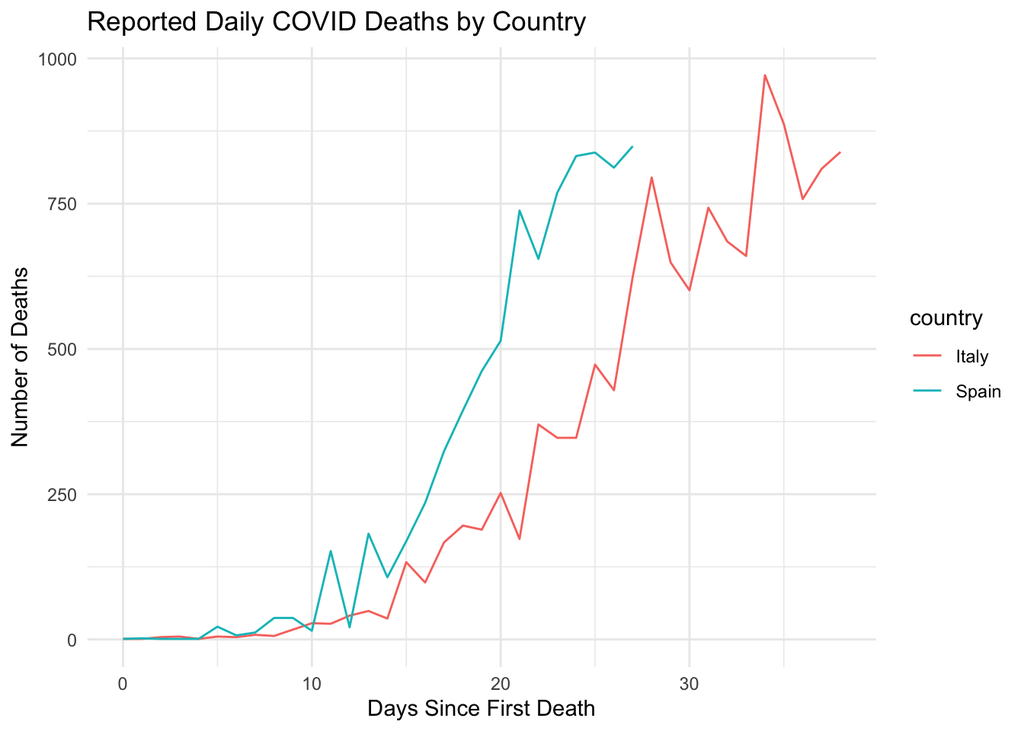

```r
ggplot(covid)+
  geom_line(aes(x=days_since_first_death,
                y = deaths,
                color= country)) +
  labs(title="Reported Daily COVID Deaths by Country",
       x='Days Since First Death',
       y='Number of Deaths')+
  theme_minimal()
```

# Problem 3

In light of the data, the estimated price elasticity demand for milk is -1.62, meaning consumers want to buy 1.62% less milk, on average, when the price increases by 1%. The 95% bootstrapped confidence interval for this quantity is -1.772 to -1.454. I first plotted the data on a log-log scale to ensure that the data looked linear and a power law is applicable to the data. I then fit a linear model to the log(sales) versus the log(price) to get the estimated elasticity of -1.62. I then bootstrapped this linear model to obtain my 95% confidence interval.